None

# ANN Building Blocks

# Biological Neurons

[figure not shown]

## Algorithm

- *Multiple input (on/off):*
  - from 1-several neurons
- *Processing*:
  - *Combination*: of inputs
  - *Activation*: on or off state
- *Single output (on/off):* to 1-several neurons

# Artificial neurons

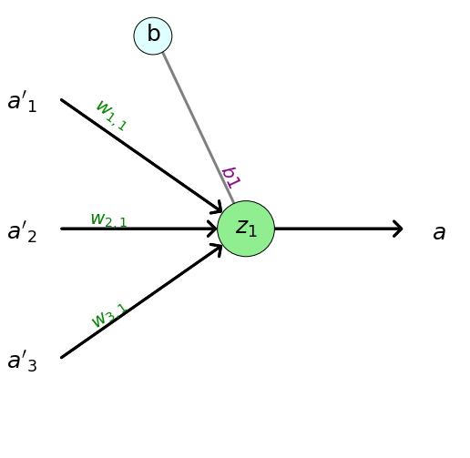

## Algorithm

- *Multiple input (on/off):*
  - from 1-several neurons
- *Processing*:
  - *Combination*: of inputs -- **linear model**
  - *Activation*: **activation function**
- *Single output (on/off):* to 1-several neurons

#### Weighted linear combination of input:

$\begin{eqnarray} z_j &=& \sum_{i} w_{i,j} a_{i} + b_j\\ \textrm{weights}&& w_{i,j}\\ \textrm{bias}&& b_j \end{eqnarray}$

#### Sigmoid (logistic) activation function:

$a_j = \sigma(z_j)$

# The Sigmoid Neuron

##### Weighted linear combination of input:

$z_j = \sum_{i} w_{i,j} a'_{i} + b_j$

##### Sigmoid/logistic activation function

$a_j=\sigma(z_j) = \frac{1}{1+e^{-z_j}}$

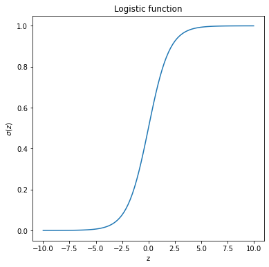

### Compare with logistic GLM

##### Weighted linear combination of input:

$z = \sum_{i} \beta_{i} x_{i} + \alpha$

##### Sigmoid/logistic link function

$Pr[y=1|x] = p = \sigma(z) = \frac{1}{1+e^{-z}}$

##### ... or equivalently

$\begin{eqnarray} \sigma^{-1}(p)&=&\log\left(\frac{p}{1-p}\right) =\\ logit(p) &=& \sum_{i}\beta_{i} x_{i} + \alpha \end{eqnarray}$

# Example

Let inputs be:  
$\begin{eqnarray} a'_1&=&1\\ a'_2&=&0\\ a'_3&=&1 \end{eqnarray}$

and we have  
$\begin{eqnarray} z_1 &=& \sum_i w_{i,1}a'_i + b_1\\ a_1 &=& \sigma(z_1) \end{eqnarray}$

$z_1 = 0.3 \times 1 + 0.8 \times 0 + 0.2 \times 1 - 0.5 = ? $

$a_1 = \sigma(z_1) = ?$

# Example

Let inputs be:  
$\begin{eqnarray} a'_1&=&1\\ a'_2&=&0\\ a'_3&=&1 \end{eqnarray}$

and we have  
$\begin{eqnarray} z_1 &=& \sum_i w_{i,1}a'_i + b_1\\ a_1 &=& \sigma(z_1) \end{eqnarray}$

$z_1 = 0.3 \times 1 + 0.8 \times 0 + 0.2 \times 1 - 0.5 = 0$

$a_1 = \sigma(z_1) = \frac{1}{1+e^{-0}} = ?$

# Example

Let inputs be:  
$\begin{eqnarray} a'_1&=&1\\ a'_2&=&0\\ a'_3&=&1 \end{eqnarray}$

and we have  
$\begin{eqnarray} z_1 &=& \sum_i w_{i,1}a'_i + b_1\\ a_1 &=& \sigma(z_1) \end{eqnarray}$

$z_1 = 0.3 \times 1 + 0.8 \times 0 + 0.2 \times 1 - 0.5 = 0$

$a_1 = \sigma(z_1) = \frac{1}{1+e^{-0}} = 0.5$

#### So, if a sigmoid artificial neuron is just another way of doing logistic regression?

#### ... then what's all the fuzz about?

#### The *fuzz* happens when you connect several neurons into a network

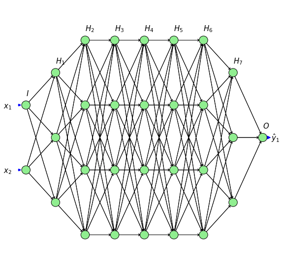

# Feed-forward artifical neural networks (ffANN)

### Layers

- "Columns" of 1-many neurons

##### A single *Input layer*

- Input neurons receives *data input* and passes it to next layer

##### 1-many *Hidden layer(s)*

- Articial neurons process their input and deliver output to next layer

##### A single *Output layer*

- Artifical neurons process their input and deliver final output $\hat{y}$
  - output $\hat{y}_j = a_j$
  - Continuous $\hat{y}$: **Regression**
  - Discrete $\hat{y}$: **Classification**

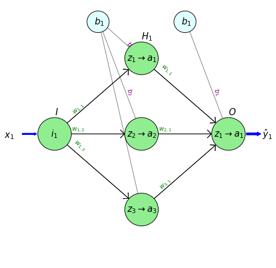

#### Connectivity between layers

- ffANN are fully connected
  - each neuron in a layer is connected to each neurons in next layer

#### ffANN examples

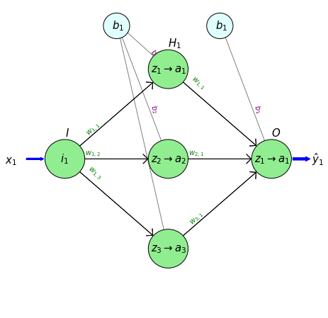

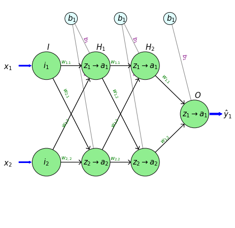

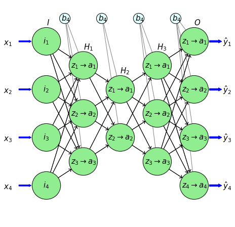

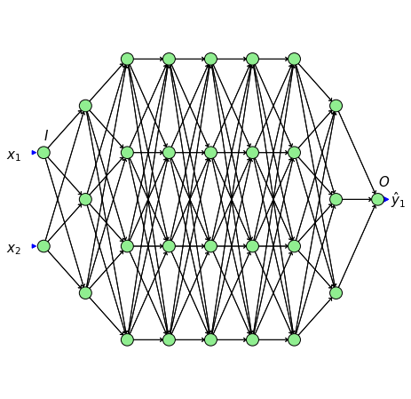

# Hidden Layers

### Inutitive function of hidden layers?

- Each layer can be viewed as transforming the original data to a new multi-dimensional space.

### Depth

- number of hidden layers

### Deep Learning

- ANNs with depth > 1

# Why deep Learning?

#### For Regression

- Single layer $\approx$ logistic regression

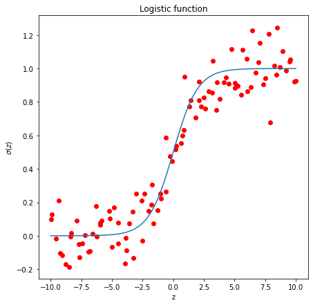

# Why deep Learning?

#### For Regression

- Single layer $\approx$ logistic regression
- More layers $\rightarrow$
  - more complex, non-linear, models

# Why deep Learning?

#### For Regression

- Single layer $\approx$ logistic regression
- More layers $\rightarrow$
  - more complex, non-linear, models

#### For classification

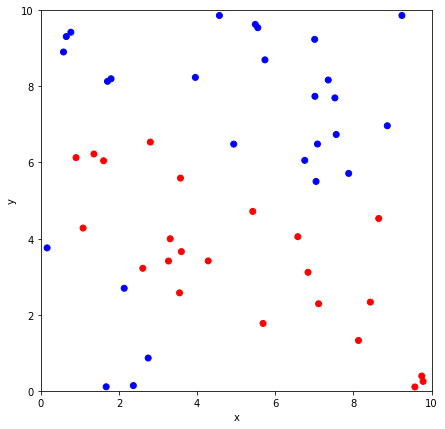

# Why deep Learning?

#### For Regression

- Single layer $\approx$ logistic regression
- More layers $\rightarrow$
  - more complex, non-linear, models

#### For classification

- Single layer $\approx$ one hyper-plane

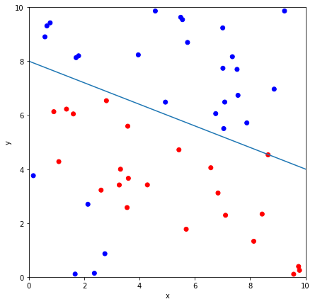

# Why deep Learning?

#### For Regression

- Single layer $\approx$ logistic regression
- More layers $\rightarrow$
  - more complex, non-linear, models

#### For classification

- Single layer $\approx$ one hyper-plane
- Adding layers $\rightarrow$
  - more hyper planes $\rightarrow$
  - more advanced classification

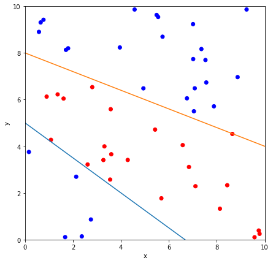

# Summary

#### Sigmoid neuron is a logistic model

\begin{eqnarray} z_i &=& \sum_j w_{ij}a'_j+b_i\\ a_i &=& \sigma(z_i) \end{eqnarray}

#### Feedforward ANN

- Neurons arranged into layers
  - Input layer (I, single)
  - Output layer (O, single)
  - Hidden layers (H, 1-many)
- Each hidden layer transforms the input into a new multi-dimensional space (a new hyperplane) which is fed to the next layer
- Output $y$, where
  - $\hat{y_j} = a_j$ for neuron $j$ in the output layer
  - *regression* or *classification*

#### Parameters

- $\{w_{i,j}\}$ and $\{b_{j}\}$ for all layers

# Mini exercise

- http://playground.tensorflow.org/
  - Test different input "problems"
  - Investigate how different depth affect classification
  - Run for several epochs (=iterations)
  - Focus on sigmoid activation, and 2-dimensional input, classification
  - (Note how loss/cost function (error of the ANN) changes)